# Prospective Profiling of Data-Poor Chemicals

Jesse Rogers

December 28, 2023

Assessment of prospective chemical screening data for chemicals predicted to perturb key molecular targets in high-throughtput transcriptomics.

# 1 Setup Environment

```r
# import packages for visualization
# (note that other required packages will be imported by pipeline scripts)
library(ggplot2)
library(dplyr)
library(tidyr)
library(readxl)
library(RColorBrewer)
library(ggrepel)

# set directories (`dir_home` should be set to the top-level directory)
dir_home <- "~/NAM-integration/NAM-integration-pilot-packaged/"
dir_scripts <- paste0(dir_home, "scripts/")
setwd(dir_home)

source(paste0(dir_scripts, "pipeline_RCAS_profiling.R"))

# set paths for rcas/framework results
path_rcas <- c(
  paste0(dir_home, "data/examples/rcas_heparg_gene.RData"),
  paste0(dir_home, "data/examples/rcas_u2os_gene.RData")
)
path_export <- paste0(
  dir_home,
  c(
    "data/examples/framework_heparg.RData",
    "data/examples/framework_u2os.RData"
  )
)

th <- theme(text = element_text(family = "Helvetica"))
```

```r
# import rcas results
rcas_heparg <- selectRCASGenes(path_rcas[1])
rcas_u2os <- selectRCASGenes(path_rcas[2])

# import framework results
load(path_export[1])
heparg_full <- compare_full
heparg_sum <- compare_sum
load(path_export[2])
u2os_full <- compare_full
u2os_sum <- compare_sum

# incorporate reference chemical annotations into full combined df
combined_full <- rbind(
  mutate(
    heparg_full,
    source = "heparg",
    ref_class = rcas_heparg$httr.wide$ref_class[
      match(dtxsid, rcas_heparg$httr.wide$dtxsid)
    ]
  ),
  mutate(
    u2os_full,
    source = "u2os",
    ref_class = rcas_u2os$httr.wide$ref_class[
      match(dtxsid, rcas_u2os$httr.wide$dtxsid)
    ]
  )
) %>%
  mutate(source_signature = gsub("_up|_dn", "", paste0(source, "_", signature)))

combined_sum <- rbind(
  mutate(heparg_sum, source = "heparg"),
  mutate(u2os_sum, source = "u2os")
) %>%
  mutate(
    source_signature = gsub("_up|_dn", "", paste0(source, "_", signature)),
    signature = gsub("_up|_dn", "", signature)
  )
```

## 1.1 Import Data

Data were received from Eurofins DiscoverX and Eurofins Panlabs separately as control-normalized (i.e. percent activation) values.

Importantly, DiscoverX data were received as individual replicate-level data, whereas Panlabs data were pre-averaged. Both forms are accepted by `tcplfit2`, but may potentially alter confidence intervals for potency estimates.

```r
# import chemical id table
httr_chems <- read_xlsx(
  paste0(dir_home, "data/eurofins/Eurofins_expt_chemicals_2022-04-22.xlsx"),
  sheet = "Sheet1"
)
table(httr_chems$assay_target, httr_chems$reference_type)
```

```
##
##        Negative None Positive
##   AHR         3   12        3
##   GR          3    4        3
##   hERG        3   16        3
##   RARg        3    4        3
##   RXRb        3    4        3
```

```r
# import DiscoverX (xlsx) and Panlabs (txt)
ef_dx <- read_xlsx(
  paste0(dir_home, "data/eurofins/US034-0017803-O_nhrSCAN_ _Data_Sheet.xlsx"),
  sheet = "Primary Data"
)
ef_pl <- read.table(
  paste0(dir_home, "data/eurofins/US034-0017803.TXT"),
  sep = "\t",
  header = TRUE,
  stringsAsFactors = FALSE
)

# import sample keys
key_dx <- read_xlsx(
  paste0(dir_home, "data/eurofins/EPA_778506_EurofinsUS_30_20220915_key.xlsx"),
  sheet = "Order594-Mosaic 778506 & 778507"
)
key_pl <- read_xlsx(
  paste0(dir_home, "data/eurofins/EPA_778508_EurofinsUS_32_20220915_key_revised.xlsx"),
  sheet = "Order595-Mosaic 778508 & 779139"
)
```

## 1.2 Harmonize Data

Individual tables are harmonized for matching structure as well as to match expected inputs for concentration-response profiling via `tcplfit2`. Assay component endpoint names (`aenm` column) are also constructed to match naming conventions in invitrodb v4.1.

```r
# format DiscoverX data:
  # pivot replicate-level data to long form
  # construct aenms
  # add chemical identifiers from sample key
  # harmonize columns/colnames
proc_dx <- ef_dx %>%
  pivot_longer(
    cols = c(`Value 1`, `Value 2`),
    names_to = "repi",
    values_to = "resp"
  ) %>%
  mutate(
    repi = gsub("Value ", "", repi),
    aenm = paste0("EF_DX_NR_h", `Assay Target`)
  ) %>%
  left_join(
    ., select(key_dx, EPA_SAMPLE_ID, DTXSID, PREFERRED_NAME),
    by = c("Compound Name" = "EPA_SAMPLE_ID")
  ) %>%
  select(
    aenm, `Compound Name`, DTXSID, PREFERRED_NAME,
    repi, `Conc(uM)`, resp, `% Efficacy`
  )
colnames(proc_dx) <- c(
  "aenm", "sample_id", "dtxsid", "name",
  "repi", "conc", "resp", "resp.pc"
)

proc_dx %>%
  arrange(aenm, dtxsid, repi, conc) %>%
  mutate(across(where(is.numeric), ~ signif(.x, 3))) %>%
  DT::datatable()
```

|  | aenm | sample_id | dtxsid | name | repi | conc | resp | resp.pc |
| --- | --- | --- | --- | --- | --- | --- | --- | --- |
| 1 | EF_DX_NR_hAHR | EPAPLT0842A01 | DTXSID0020862 | 3-Methylcholanthrene | 1 | 0.301 | 80500 | 12.3 |
| 2 | EF_DX_NR_hAHR | EPAPLT0842A01 | DTXSID0020862 | 3-Methylcholanthrene | 1 | 0.951 | 146000 | 37.7 |
| 3 | EF_DX_NR_hAHR | EPAPLT0842A01 | DTXSID0020862 | 3-Methylcholanthrene | 1 | 3 | 241000 | 71.3 |
| 4 | EF_DX_NR_hAHR | EPAPLT0842A01 | DTXSID0020862 | 3-Methylcholanthrene | 1 | 9.49 | 267000 | 73.3 |
| 5 | EF_DX_NR_hAHR | EPAPLT0842A01 | DTXSID0020862 | 3-Methylcholanthrene | 1 | 30 | 269000 | 79.9 |
| 6 | EF_DX_NR_hAHR | EPAPLT0842A01 | DTXSID0020862 | 3-Methylcholanthrene | 2 | 0.301 | 88000 | 12.3 |
| 7 | EF_DX_NR_hAHR | EPAPLT0842A01 | DTXSID0020862 | 3-Methylcholanthrene | 2 | 0.951 | 169000 | 37.7 |
| 8 | EF_DX_NR_hAHR | EPAPLT0842A01 | DTXSID0020862 | 3-Methylcholanthrene | 2 | 3 | 270000 | 71.3 |
| 9 | EF_DX_NR_hAHR | EPAPLT0842A01 | DTXSID0020862 | 3-Methylcholanthrene | 2 | 9.49 | 255000 | 73.3 |
| 10 | EF_DX_NR_hAHR | EPAPLT0842A01 | DTXSID0020862 | 3-Methylcholanthrene | 2 | 30 | 291000 | 79.9 |

[output cut: 290 more lines]

```r
# format Panlabs data:
  # pivot agonist/antagonist modes to long-form + remove missing rows
  # construct assay metadata columns
  # construct aenms
  # add chemical identifiers from sample key
  # harmonize columns/colnames
proc_pl <- ef_pl %>%
  as_tibble() %>%
  pivot_longer(
    cols = c(Agonist.Response, Antagonist.Response),
    names_to = "endpoint",
    values_to = "resp.pc"
  ) %>%
  filter(!is.na(resp.pc)) %>%
  mutate(
    repi = "12",
    replicate_id = paste0(Compound.Code, "_", repi),
    endpoint = gsub(".Response", "", endpoint),
    target = case_when(
      grepl("hERG", Ascii.Assay.Name) ~ "KCNH2",
      grepl("RARG", Ascii.Assay.Name) ~ "RARG",
      grepl("RXRbeta", Ascii.Assay.Name) ~ "RXRB"
    ),
    aenm = case_when(
      `Route.of.Administration` == "Radioligand Binding" ~ paste0("ERF_PL_IC_h", target),
      TRUE ~ paste0("ERF_PL_NR_COA_h", target)
    ),
    resp = NA
  ) %>%
  left_join(
    ., select(key_pl, EPA_SAMPLE_ID, DTXSID, PREFERRED_NAME),
    by = c("Compound.Code" = "EPA_SAMPLE_ID")
  ) %>%
  select(
    aenm, Compound.Code, DTXSID, PREFERRED_NAME,
    repi, Concentration.of.Test.Compound, resp, resp.pc
  )
colnames(proc_pl) <- c(
  "aenm", "sample_id", "dtxsid", "name",
  "repi", "conc", "resp", "resp.pc"
)

proc_pl %>%
  arrange(aenm, dtxsid, repi, conc) %>%
  mutate(across(where(is.numeric), ~ signif(.x, 3))) %>%
  DT::datatable()
```

|  | aenm | sample_id | dtxsid | name | repi | conc | resp | resp.pc |
| --- | --- | --- | --- | --- | --- | --- | --- | --- |
| 1 | ERF_PL_IC_hKCNH2 | EPAPLT0844A01 | DTXSID0020862 | 3-Methylcholanthrene | 12 | 0.3 |  | 24.3 |
| 2 | ERF_PL_IC_hKCNH2 | EPAPLT0844A01 | DTXSID0020862 | 3-Methylcholanthrene | 12 | 1 |  | 23.5 |
| 3 | ERF_PL_IC_hKCNH2 | EPAPLT0844A01 | DTXSID0020862 | 3-Methylcholanthrene | 12 | 3 |  | 38.6 |
| 4 | ERF_PL_IC_hKCNH2 | EPAPLT0844A01 | DTXSID0020862 | 3-Methylcholanthrene | 12 | 10 |  | 24.8 |
| 5 | ERF_PL_IC_hKCNH2 | EPAPLT0844A01 | DTXSID0020862 | 3-Methylcholanthrene | 12 | 30 |  | 46.7 |
| 6 | ERF_PL_IC_hKCNH2 | EPAPLT0844A02 | DTXSID0034223 | Tebufenpyrad | 12 | 0.3 |  | -13.7 |
| 7 | ERF_PL_IC_hKCNH2 | EPAPLT0844A02 | DTXSID0034223 | Tebufenpyrad | 12 | 1 |  | -7.7 |
| 8 | ERF_PL_IC_hKCNH2 | EPAPLT0844A02 | DTXSID0034223 | Tebufenpyrad | 12 | 3 |  | 1.8 |
| 9 | ERF_PL_IC_hKCNH2 | EPAPLT0844A02 | DTXSID0034223 | Tebufenpyrad | 12 | 10 |  | 29.2 |
| 10 | ERF_PL_IC_hKCNH2 | EPAPLT0844A02 | DTXSID0034223 | Tebufenpyrad | 12 | 30 |  | 86.1 |

[output cut: 200 more lines]

```r
proc_all <- rbind(proc_dx, proc_pl)

# define concentration indices (cndx) + log-scale conc (logc)
proc_all <- proc_all %>%
  group_by(aenm, dtxsid, repi) %>%
  mutate(
    sample_repi_id = paste0(sample_id, "_", repi),
    cndx = row_number(conc),
    logc = log10(conc)
  )
```

# 2 Conduct Concentration-Response Profiling

## 2.1 Determine response cutoff levels

Baseline median absolute deviations (BMADs) are determined for each assay from response values using the 2 lowest concentrations of all test chemicals, as well-level data is not reported for positive/negative controls.

Because cutoff levels can be high due to the biased selection of chemicals likely to demonstrate bioactivity in each assay, minimum and maximum thresholds are employed for each cutoff:

[output not shown]

```r
# define bmad + onesd + cutoff from lowest 2 concentrations
bmads <- proc_all %>%
  group_by(aenm) %>%
  filter(cndx <= 2) %>%
  summarise(
    bmad = mad(resp.pc),
    bmad3 = 3 * bmad,
    onesd = sd(resp.pc),
    cutoff = case_when(
      bmad3 < 20 ~ 20,
      bmad3 > 50 ~ 50,
      TRUE ~ bmad3
    )
  )
proc_all <- left_join(proc_all, bmads, by = "aenm")
bmads %>%
  mutate(across(-aenm, ~ signif(.x, 3))) %>%
  DT::datatable()
```

|  | aenm | bmad | bmad3 | onesd | cutoff |
| --- | --- | --- | --- | --- | --- |
| 1 | EF_DX_NR_hAHR | 8.01 | 24 | 19.5 | 24 |
| 2 | EF_DX_NR_hGR | 44.3 | 133 | 40.2 | 50 |
| 3 | ERF_PL_IC_hKCNH2 | 15.3 | 46 | 34.4 | 46 |
| 4 | ERF_PL_NR_COA_hRARG | 7.34 | 22 | 48.4 | 22 |
| 5 | ERF_PL_NR_COA_hRXRB | 0.667 | 2 | 33.1 | 20 |

## 2.2 Perform curve-fitting

```r
fit_all <- data.frame()
for (aenm_fit in unique(proc_all$aenm)) {
  proc_aenm <- filter(proc_all, aenm == aenm_fit)
  for (spid_fit in unique(proc_aenm$sample_id)) {
    proc_spid <- arrange(filter(proc_aenm, sample_id == spid_fit), conc)
    # pull conc/resp/noise data into list object
    dat.obj <- list(
      conc = proc_spid$conc,
      resp = proc_spid$resp.pc,
      bmed = 0,
      cutoff = unique(proc_spid$cutoff),
      onesd = unique(proc_spid$onesd),
      aenm = aenm_fit,
      dtxsid = unique(proc_spid$dtxsid),
      casrn = NA,
      name = unique(proc_spid$name)
    )
    # run CR modeling (no gnls model)
    res <- concRespCore(
      dat.obj,
      fitmodels = c(
        "cnst", "hill", "poly1", "poly2", "pow", "exp2", "exp3", "exp4", "exp5"
      )
    )
    rownames(res) <- NULL
    # store results in final df
    fit_all <- rbind(fit_all, res)
  }
}
```

# 3 Analyze Results

```r
# get Tier 1 results matching prospective chemicals/assays
tier1_chems <- httr_chems %>%
  mutate(
    signature = case_when(
      assay_target == "AHR" ~ "AHR_Agonist",
      assay_target == "GR" ~ "NR3C1_Agonist",
      assay_target == "hERG" ~ "hERG_Inhibitor",
      TRUE ~ "RAR_RXR_Agonist"
    )
  ) %>%
  left_join(
    ., select(
      combined_sum,
      dtxsid, signature, bmd_log, n_toxcast_meas,
      outcome_tier1, outcome_tier2, source_signature
    ),
    by = c("dtxsid", "signature"),
    relationship = "many-to-many"
  )
# de-duplicate Tier 1 results for multiple RAR/RXR signatures
tier1_chems <- tier1_chems %>%
  group_by(dtxsid, assay_target) %>%
  slice_min(bmd_log, n = 1) %>%
  ungroup()

# incorporate prospective profiling results
combined_prosp <- fit_all %>%
  mutate(
    assay_target = case_when(
      grepl("AHR", aenm) ~ "AHR",
      grepl("GR", aenm) ~ "GR",
      grepl("KCNH2", aenm) ~ "hERG",
      grepl("RARG", aenm) ~ "RARg",
      grepl("RXRB", aenm) ~ "RXRb"
    ),
    outcome_prosp = ifelse(
      hitcall >= 0.9 & top_over_cutoff >= 1, "Positive", "Negative"
    )
  ) %>%
  select(
    dtxsid, assay_target, aenm, hitcall,
    top_over_cutoff, acc, bmd, outcome_prosp
  ) %>%
  left_join(tier1_chems, ., by = c("dtxsid", "assay_target"))
```

## 3.1 Classification of test chemicals

Chemical bioactivity classifications are defined as a continuous hitcall >= 0.9 and top_over_cutoff >= 1.

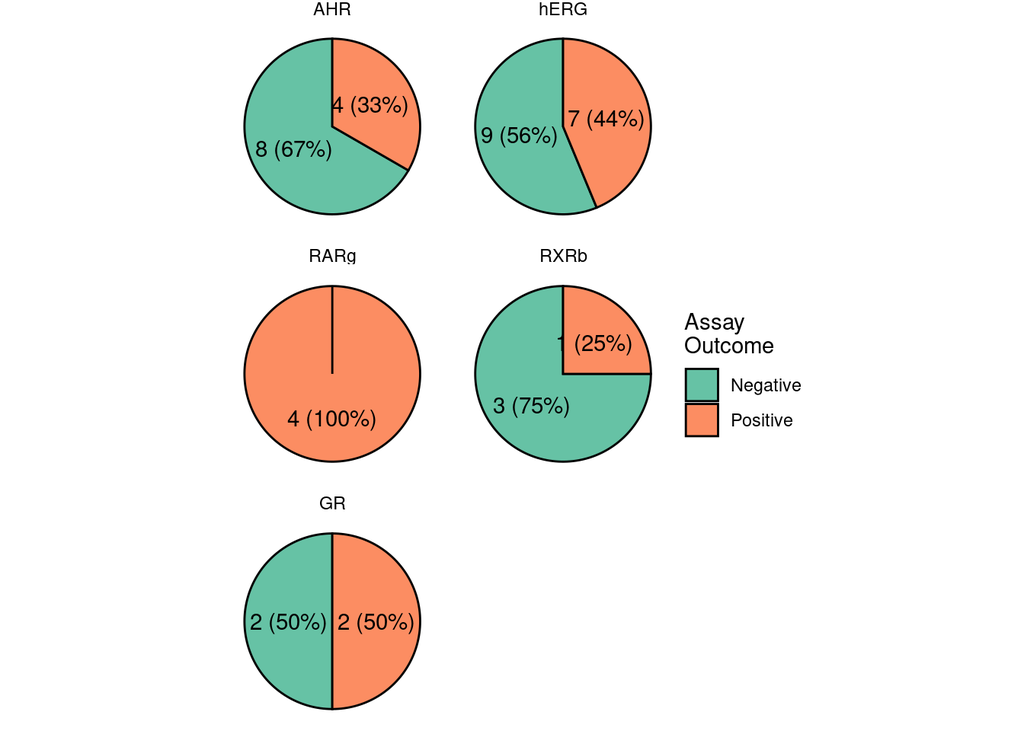

```r
# compare classification results as pie charts
plot_class <- combined_prosp %>%
  filter(reference_type == "None") %>%
  mutate(
    target_f = factor(
      assay_target, levels = c("AHR", "hERG", "RARg", "RXRb", "GR")
    )
  ) %>%
  count(target_f, outcome_prosp) %>%
  complete(target_f, outcome_prosp, fill = list(n = 0)) %>%
  group_by(target_f) %>%
  mutate(
    n_sum = sum(n),
    prop = n / n_sum,
    prop_label = case_when(
      prop > 0 ~ paste0(n, " (", round(prop * 100), "%)"),
      TRUE ~ ""
    )
  ) %>%
  ggplot(aes(x = "", y = prop, fill = outcome_prosp, label = prop_label)) +
  geom_col(color = "black") +
  coord_polar(theta = "y") +
  geom_text(position = position_stack(vjust = 0.5), family = "Helvetica") +
  facet_wrap(~target_f, nrow = 3) +
  scale_fill_brewer(palette = "Set2") +
  # scale_color_manual(values = c("black", "white")) +
  labs(x = "", y = "", fill = "Assay\nOutcome") +
  theme_void() +
  th

plot_class
```

## 3.2 Sensitivity of Potency Estimates

Tier 1 RCAS-derived PODs (`bmd_log`) are compared to potency values from prospective assays to assess the relative sensitivity of each tiered result.

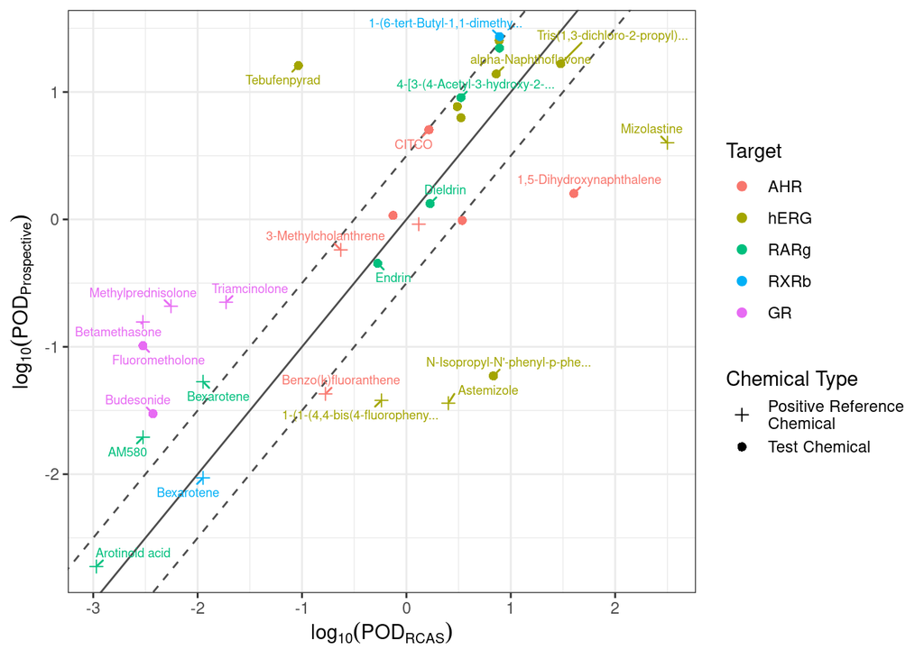

```r
# visualize trends between potency estimates
plot_potency <- combined_prosp %>%
  filter(outcome_prosp == "Positive") %>%
  mutate(
    acc_log = log10(acc),
    reference_type = case_when(
      reference_type == "None" ~ "Test Chemical",
      TRUE ~ "Positive Reference\nChemical"
    ),
    target_f = factor(
      assay_target, levels = c("AHR", "hERG", "RARg", "RXRb", "GR")
    )
  ) %>%
  ggplot(
    aes(
      bmd_log, acc_log,
      color = target_f, shape = reference_type,
      label = stringr::str_trunc(name, 30)
    )
  ) +
  geom_abline(slope = 1, intercept = 0, color = "grey30") +
  geom_abline(
    slope = 1, intercept = c(-0.5, 0.5), color = "grey30", linetype = "dashed"
  ) +
  geom_point(size = 2) +
  geom_text_repel(min.segment.length = 0, size = 2.4, max.overlaps = 5, box.padding = 0.28) +
  scale_shape_manual(values = c(3, 16, 4)) +
  labs(
    x = expression(log[10](POD[RCAS])),
    y = expression(log[10](POD[Prospective])),
    color = "Target", shape = "Chemical Type"
  ) +
  theme_bw() +
  th

plot_potency
```

Spearman correlation coefficients of potency metrics are also determined per assay.

```r
cor_potency <- combined_prosp %>%
  filter(outcome_prosp == "Positive") %>%
  mutate(
    acc_log = log10(acc),
    target_f = factor(
      assay_target,
      levels = c("AHR", "hERG", "RARg", "RXRb", "GR")
    )
  ) %>%
  group_by(target_f) %>%
  mutate(n_active = n()) %>%
  filter(n_active >= 3) %>%
  nest() %>%
  mutate(
    cor_obj = purrr::map(
      data, function(x) cor.test(x$bmd_log, x$acc_log, method = "spearman")
    ),
    cor_df = purrr::map(cor_obj, broom::tidy)
  ) %>%
  unnest(cor_df) %>%
  select(target_f, estimate, p.value)
cor_potency %>%
  mutate(across(c(estimate, p.value), ~ signif(.x, 2))) %>%
  DT::datatable()
```

|  | target_f | estimate | p.value |
| --- | --- | --- | --- |
| 1 | AHR | 0.75 | 0.066 |
| 2 | hERG | 0.36 | 0.31 |
| 3 | RARg | 1 | 0.0004 |
| 4 | GR | 0.67 | 0.22 |

```r
# plot correlation table as grob
tt <- gridExtra::ttheme_default(base_family = "Helvetica")
plot_cor <- cor_potency %>%
  mutate(
    estimate = signif(estimate, 2),
    p.value = case_when(
      p.value < 0.001 ~ formatC(p.value, format = "e", digits = 2),
      TRUE ~ as.character(signif(p.value, 2))
    )
  ) %>%
  rename(Target = target_f, `Spearman r` = estimate, `p-value` = p.value) %>%
  gridExtra::tableGrob(., rows = NULL, theme = tt)

# combine individual plots into single figure (Fig. 6)
plot_all <- cowplot::plot_grid(
  plot_class,
  cowplot::plot_grid(
    NULL, plot_potency, plot_cor,
    ncol = 1, labels = c("B", "", "C"), rel_heights = c(0.2, 1, 0.8),
    label_fontfamily = "Helvetica"
  ),
  labels = c("A", ""), ncol = 2, label_fontfamily = "Helvetica"
)
ggsave(
  paste0(dir_home, "output/Fig6.png"), plot_all,
  width = 1400, height = 960, units = "px", scale = 2, bg = "white"
)
```